# FMWT drought stuff

## Longfin Smelt

I know Jereme doesn’t like the annual FMWT index, but it’s really easy to work with. I am also curious to see whether it tells a similar story to the Baesyian analysis of all the station data that Jereme is working up, so here goes.

I’ll just grab the FMWT indexes and attach the water year types based on my drought/wet assignments and the Sac Valley index.

```r
FMWT = read.csv("data/FMWTindices.csv")

#Year types are based on water year, whereas the FMWT is probably most senstative
#to the previous water year (so FMWT for Calendar Year 2020 is most sensative to water year 2020)
yeartypes = read_excel("data/Integrated data set.xlsx", sheet = "yearassignments")

FMWT = left_join(FMWT, yeartypes) %>%
  filter(Year > 1969)
```

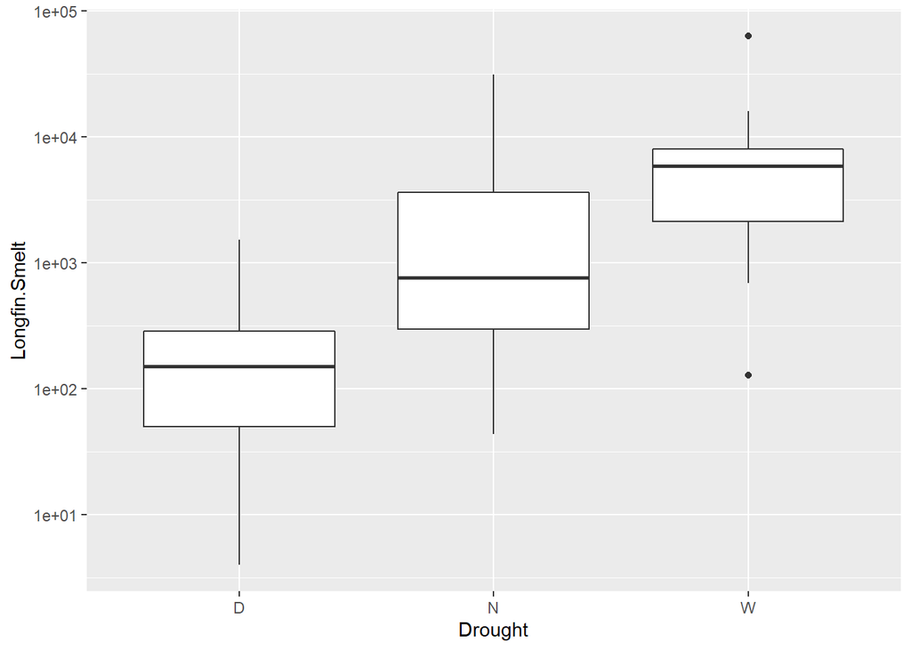

```r
#make a quick box plot
ggplot(FMWT, aes(x = Drought, y = Longfin.Smelt)) + geom_boxplot() + scale_y_log10()
```

## Data exploration

It probably isn’t normally distributed, but probably not zero-inflated either.

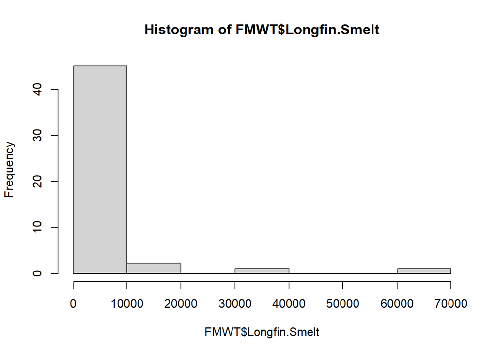

```r
hist(FMWT$Longfin.Smelt)
```

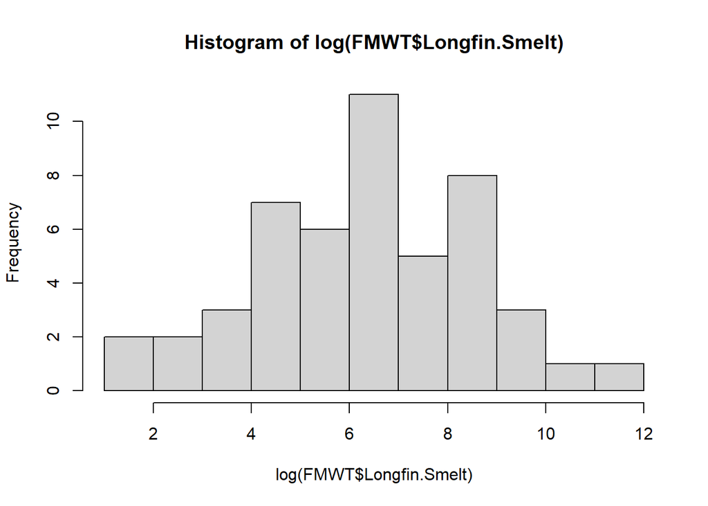

```r
hist(log(FMWT$Longfin.Smelt))
```

wow. That actually looks pretty nice.

# Now some models.

First just log-transformed linear models. I know they are dorky, but they are also easy.

I’ll do an ANOVA on drought/nutral/wet as well as a linear model on Sac valley index.

```r
l1 = lm(log(Longfin.Smelt)~Drought, data = FMWT)
summary(l1)
```

```
##
## Call:
## lm(formula = log(Longfin.Smelt) ~ Drought, data = FMWT)
##
## Residuals:
##     Min      1Q  Median      3Q     Max
## -3.4573 -0.7421  0.1816  0.9627  3.6132
##
## Coefficients:
##             Estimate Std. Error t value Pr(>|t|)
## (Intercept)   4.7162     0.3742  12.604  < 2e-16 ***
## DroughtN      2.0182     0.5716   3.531 0.000953 ***
## DroughtW      3.6009     0.5831   6.175 1.58e-07 ***
## ---
## Signif. codes:  0 '***' 0.001 '**' 0.01 '*' 0.05 '.' 0.1 ' ' 1
##
## Residual standard error: 1.673 on 46 degrees of freedom
##   (2 observations deleted due to missingness)
## Multiple R-squared:  0.4601, Adjusted R-squared:  0.4366
## F-statistic:  19.6 on 2 and 46 DF,  p-value: 6.968e-07
```

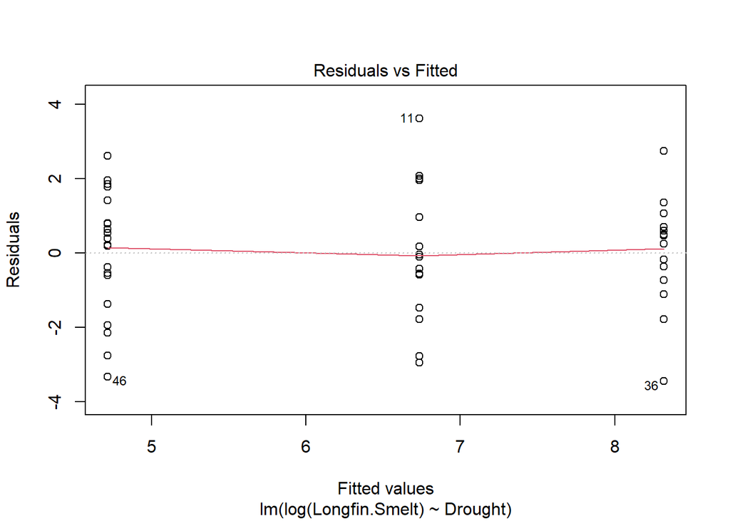

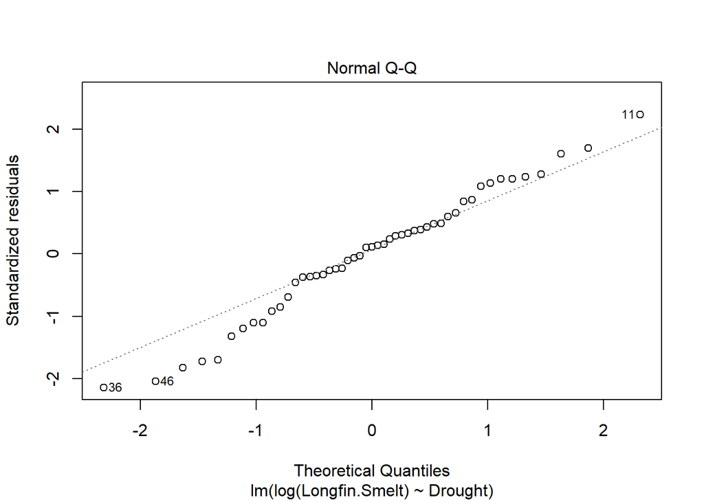

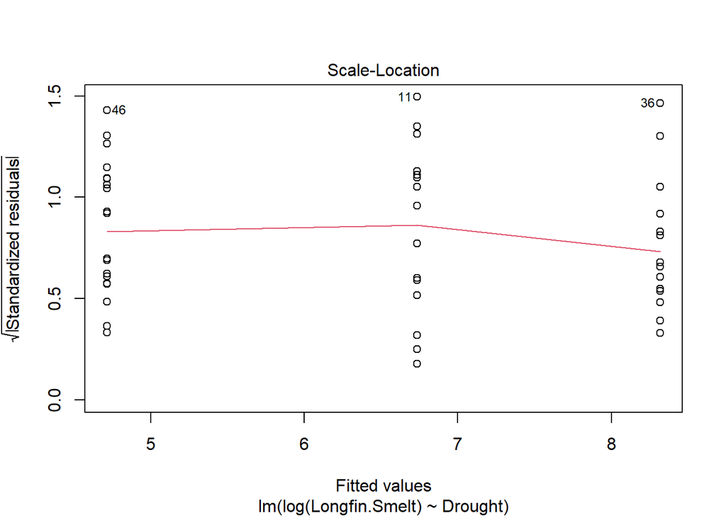

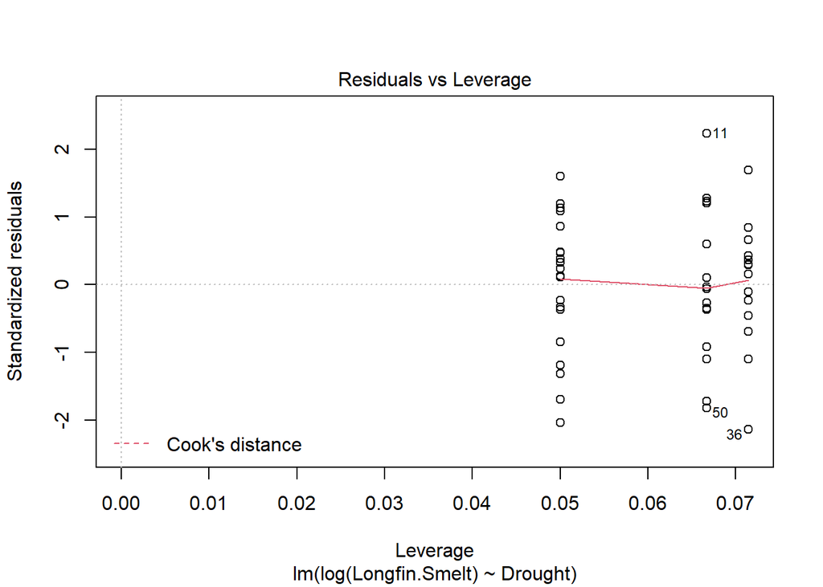

```r
plot(l1)
```

```r
emmeans(l1, pairwise ~ Drought)
```

```
## $emmeans
##  Drought emmean    SE df lower.CL upper.CL
##  D         4.72 0.374 46     3.96     5.47
##  N         6.73 0.432 46     5.86     7.60
##  W         8.32 0.447 46     7.42     9.22
##
## Results are given on the log (not the response) scale.
## Confidence level used: 0.95
##
## $contrasts
##  contrast estimate    SE df t.ratio p.value
##  D - N       -2.02 0.572 46 -3.531  0.0027
##  D - W       -3.60 0.583 46 -6.175  <.0001
##  N - W       -1.58 0.622 46 -2.545  0.0375
##
## Results are given on the log (not the response) scale.
## P value adjustment: tukey method for comparing a family of 3 estimates
```

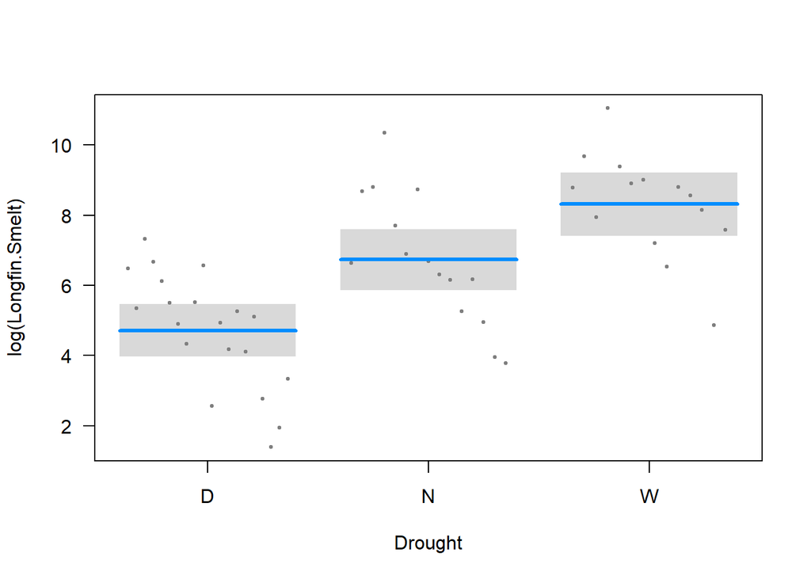

```r
visreg(l1)
```

Diagnostic plots look good on that one

Now let’s try the index

```r
l2 = lm(log(Longfin.Smelt)~Index, data = FMWT)
summary(l2)
```

```
##
## Call:
## lm(formula = log(Longfin.Smelt) ~ Index, data = FMWT)
##
## Residuals:
##     Min      1Q  Median      3Q     Max
## -4.1762 -1.1278  0.1474  1.3383  3.5128
##
## Coefficients:
##             Estimate Std. Error t value Pr(>|t|)
## (Intercept)  2.77545    0.75169   3.692 0.000578 ***
## Index        0.44905    0.08835   5.083 6.36e-06 ***
## ---
## Signif. codes:  0 '***' 0.001 '**' 0.01 '*' 0.05 '.' 0.1 ' ' 1
##
## Residual standard error: 1.81 on 47 degrees of freedom
##   (2 observations deleted due to missingness)
## Multiple R-squared:  0.3547, Adjusted R-squared:  0.341
## F-statistic: 25.83 on 1 and 47 DF,  p-value: 6.359e-06
```

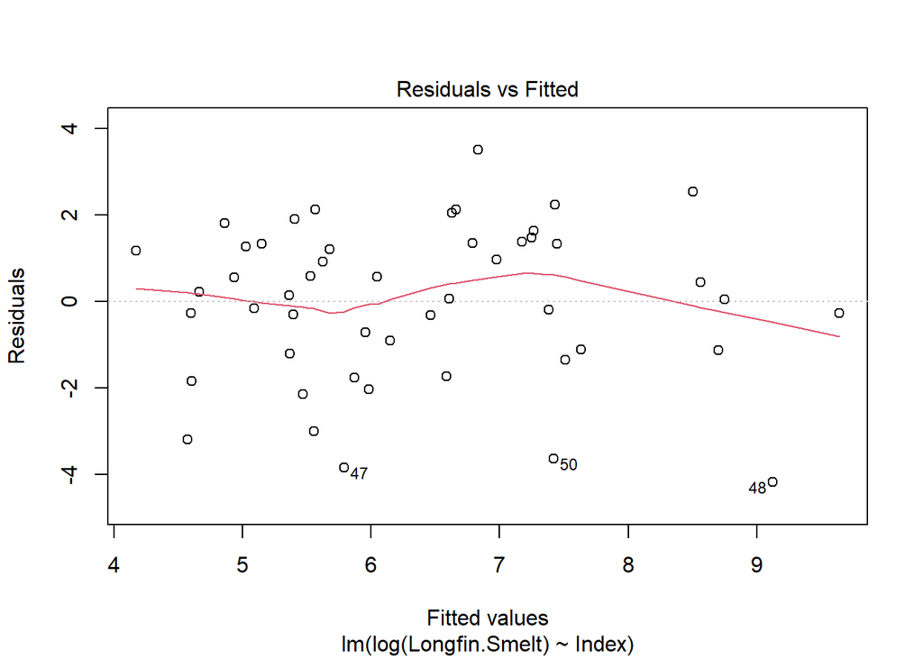

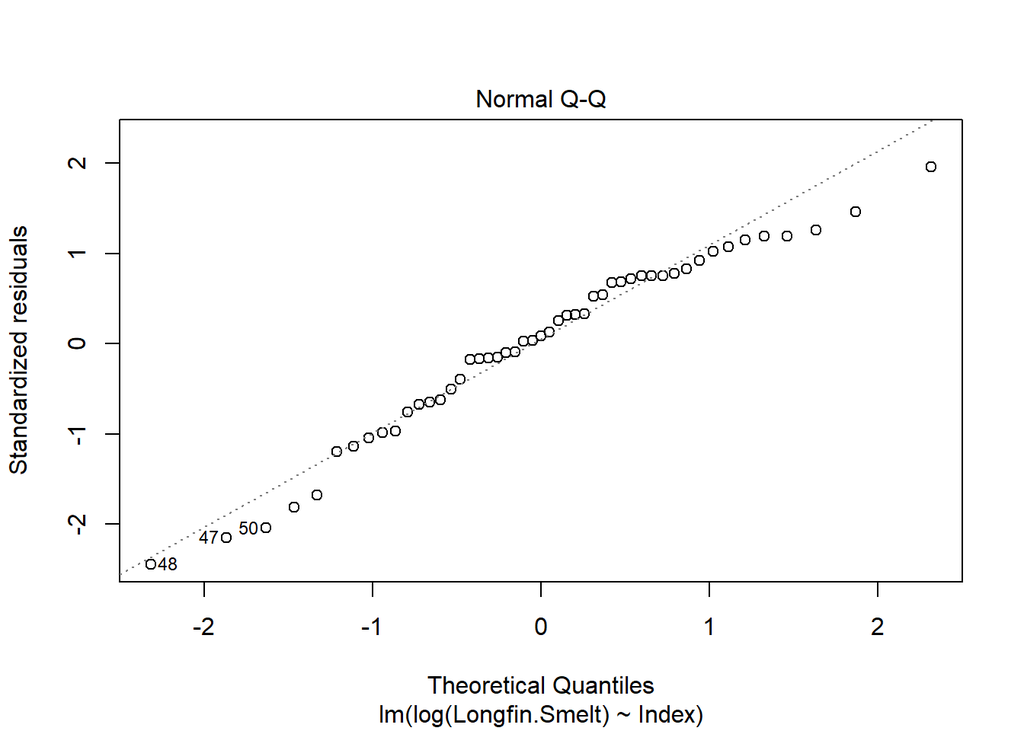

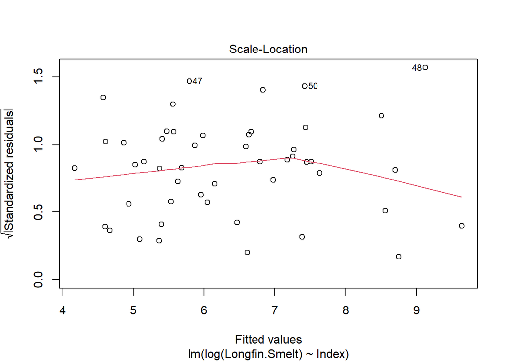

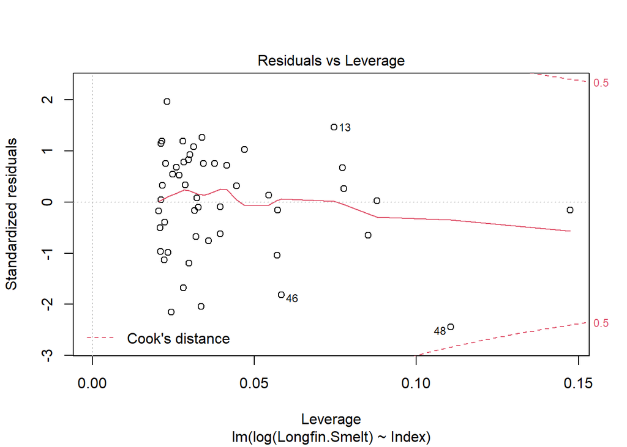

```r
plot(l2)
```

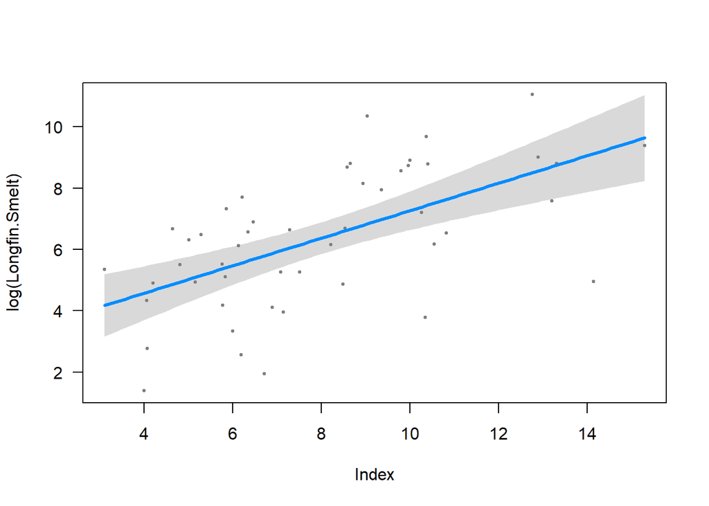

```r
visreg(l2)
```

Most real statistitions tell you not to log-transform count data. So usually Poisson or Negative binomial are th eway to go.

```r
p1 = glm(Longfin.Smelt ~ Drought, data = FMWT, family = "poisson")
summary(p1)
```

```
##
## Call:
## glm(formula = Longfin.Smelt ~ Drought, family = "poisson", data = FMWT)
##
## Deviance Residuals:
##     Min       1Q   Median       3Q      Max
## -133.88   -65.87   -21.18    -2.39   359.68
##
## Coefficients:
##             Estimate Std. Error z value Pr(>|z|)
## (Intercept)  5.65774    0.01321   428.3   <2e-16 ***
## DroughtN     2.57670    0.01386   185.9   <2e-16 ***
## DroughtW     3.51673    0.01349   260.7   <2e-16 ***
## ---
## Signif. codes:  0 '***' 0.001 '**' 0.01 '*' 0.05 '.' 0.1 ' ' 1
##
## (Dispersion parameter for poisson family taken to be 1)
##
##     Null deviance: 540763  on 48  degrees of freedom
## Residual deviance: 342542  on 46  degrees of freedom
##   (2 observations deleted due to missingness)
## AIC: 342950
##
## Number of Fisher Scoring iterations: 6
```

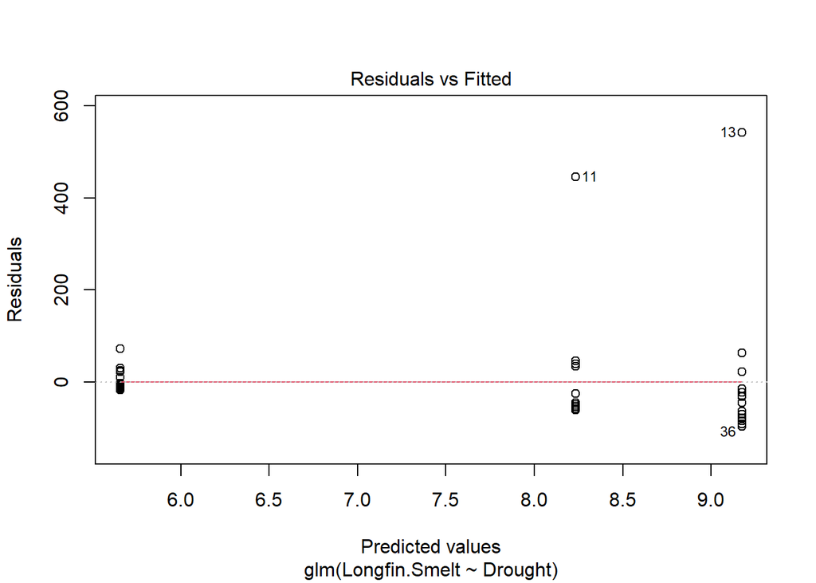

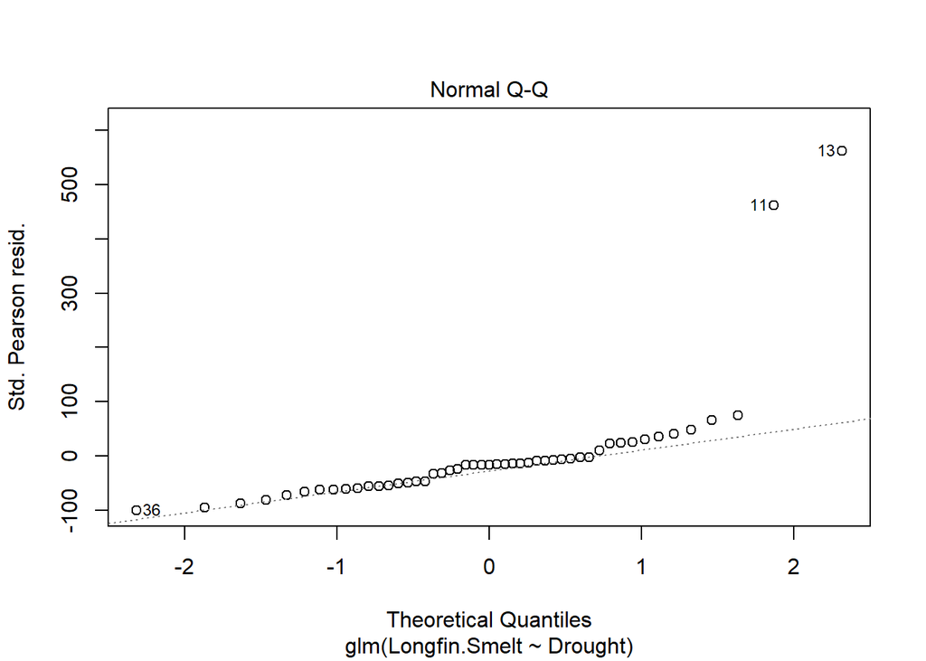

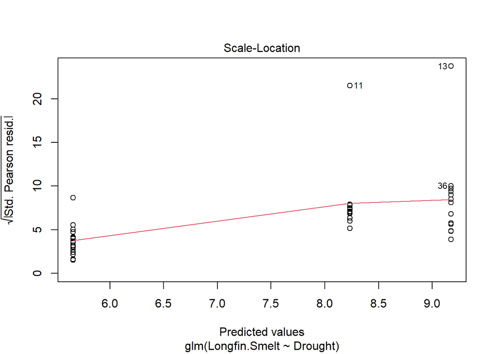

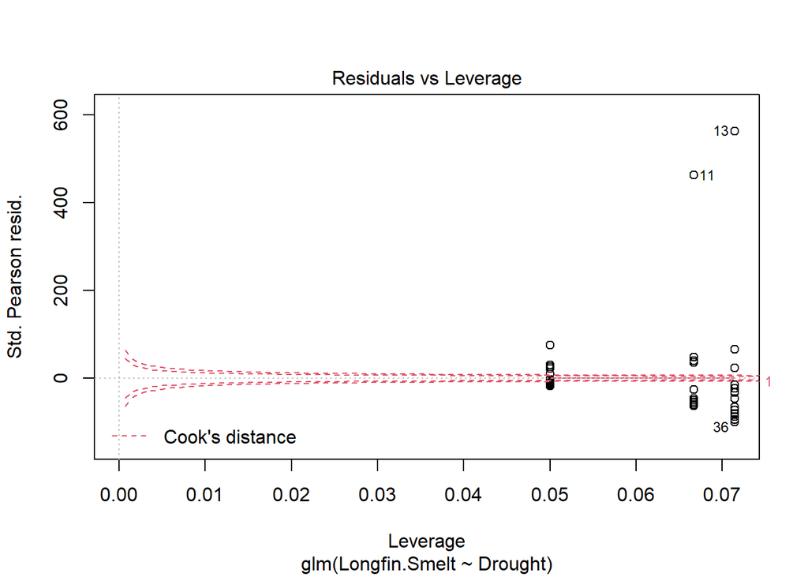

```r
plot(p1)
```

```r
#that's a big bucket of NOPE
```

Now the negative binomial. We’ll try a year effect in there too.

```r
#ok, now how about a negative binomial?

nb1 = glm.nb(Longfin.Smelt ~ Drought, data = FMWT, link = "log")
summary(nb1)
```

```
##
## Call:
## glm.nb(formula = Longfin.Smelt ~ Drought, data = FMWT, link = "log",
##     init.theta = 0.5718886596)
##
## Deviance Residuals:
##     Min       1Q   Median       3Q      Max
## -1.9881  -1.1682  -0.5096  -0.1094   2.4297
##
## Coefficients:
##             Estimate Std. Error z value Pr(>|z|)
## (Intercept)   5.6577     0.2960  19.115  < 2e-16 ***
## DroughtN      2.5767     0.4519   5.702 1.18e-08 ***
## DroughtW      3.5167     0.4610   7.629 2.37e-14 ***
## ---
## Signif. codes:  0 '***' 0.001 '**' 0.01 '*' 0.05 '.' 0.1 ' ' 1
##
## (Dispersion parameter for Negative Binomial(0.5719) family taken to be 1)
##
##     Null deviance: 108.38  on 48  degrees of freedom
## Residual deviance:  60.79  on 46  degrees of freedom
##   (2 observations deleted due to missingness)
## AIC: 823.55
##
## Number of Fisher Scoring iterations: 1
##
##
##               Theta:  0.5719
##           Std. Err.:  0.0969
##
##  2 x log-likelihood:  -815.5470
```

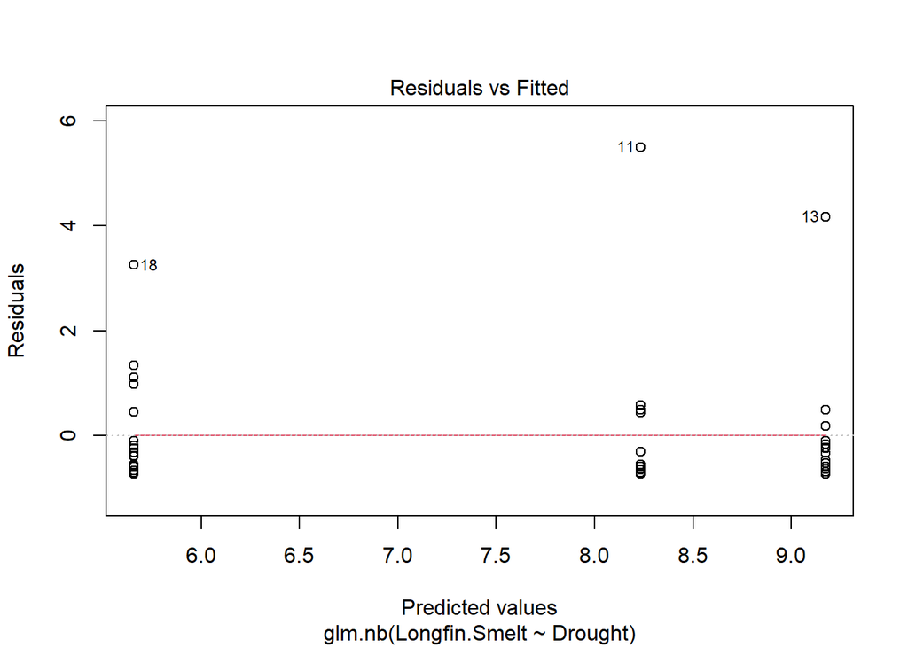

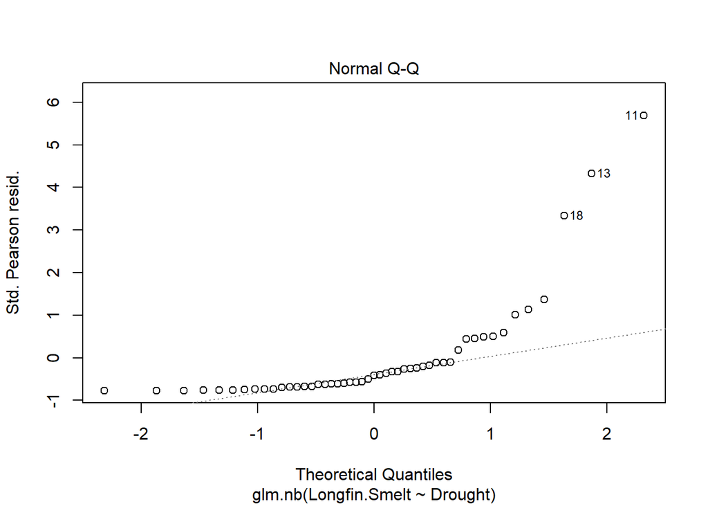

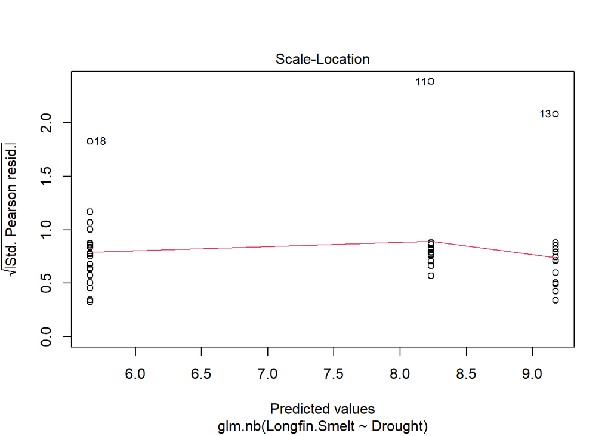

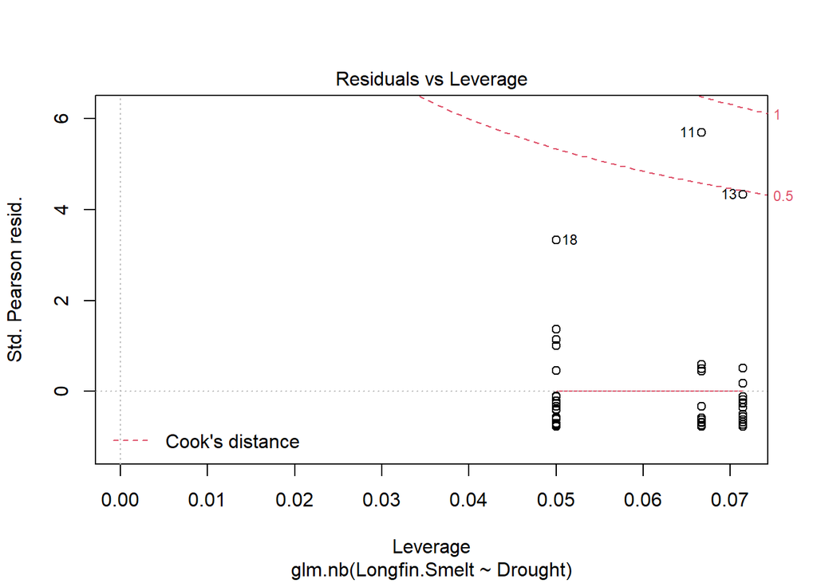

```r
plot(nb1)
```

```r
#similar to log-transformed version, but diagnostic plots don't look as good.

nb2 = glm.nb(Longfin.Smelt ~ Index, data = FMWT)
summary(nb2)
```

```
##
## Call:
## glm.nb(formula = Longfin.Smelt ~ Index, data = FMWT, init.theta = 0.5581229099,
##     link = log)
##
## Deviance Residuals:
##     Min       1Q   Median       3Q      Max
## -2.3122  -1.3069  -0.6678   0.1717   2.7464
##
## Coefficients:
##             Estimate Std. Error z value Pr(>|z|)
## (Intercept)  3.25438    0.55630   5.850 4.91e-09 ***
## Index        0.52920    0.06537   8.095 5.71e-16 ***
## ---
## Signif. codes:  0 '***' 0.001 '**' 0.01 '*' 0.05 '.' 0.1 ' ' 1
##
## (Dispersion parameter for Negative Binomial(0.5581) family taken to be 1)
##
##     Null deviance: 105.776  on 48  degrees of freedom
## Residual deviance:  61.015  on 47  degrees of freedom
##   (2 observations deleted due to missingness)
## AIC: 823.25
##
## Number of Fisher Scoring iterations: 1
##
##
##               Theta:  0.5581
##           Std. Err.:  0.0943
##
##  2 x log-likelihood:  -817.2500
```

```r
nb3 = glmer.nb(Longfin.Smelt ~ Index + (1|Year), data = FMWT)
summary(nb3)
```

```
## Generalized linear mixed model fit by maximum likelihood (Laplace
##   Approximation) [glmerMod]
##  Family: Negative Binomial(768114.6)  ( log )
## Formula: Longfin.Smelt ~ Index + (1 | Year)
##    Data: FMWT
##
##      AIC      BIC   logLik deviance df.resid
##    827.0    834.6   -409.5    819.0       45
##
## Scaled residuals:
##      Min       1Q   Median       3Q      Max
## -0.43006 -0.01973  0.00160  0.00740  0.02577
##
## Random effects:
##  Groups Name        Variance Std.Dev.
##  Year   (Intercept) 3.113    1.764
## Number of obs: 49, groups:  Year, 49
##
## Fixed effects:
##             Estimate Std. Error z value Pr(>|z|)
## (Intercept)  2.79133    0.42054   6.637 3.19e-11 ***
## Index        0.44772    0.05477   8.174 2.98e-16 ***
## ---
## Signif. codes:  0 '***' 0.001 '**' 0.01 '*' 0.05 '.' 0.1 ' ' 1
##
## Correlation of Fixed Effects:
##       (Intr)
## Index -0.841
```

```r
#not sure that's right

nb4 = glm.nb(Longfin.Smelt ~ Index + Year, data = FMWT)
summary(nb4)
```

```
##
## Call:
## glm.nb(formula = Longfin.Smelt ~ Index + Year, data = FMWT, init.theta = 1.256146273,
##     link = log)
##
## Deviance Residuals:
##     Min       1Q   Median       3Q      Max
## -1.8959  -1.1083  -0.4460   0.1651   2.2005
##
## Coefficients:
##               Estimate Std. Error z value Pr(>|z|)
## (Intercept) 205.939078  17.705886  11.631   <2e-16 ***
## Index         0.427065   0.043849   9.739   <2e-16 ***
## Year         -0.101483   0.008855 -11.461   <2e-16 ***
## ---
## Signif. codes:  0 '***' 0.001 '**' 0.01 '*' 0.05 '.' 0.1 ' ' 1
##
## (Dispersion parameter for Negative Binomial(1.2561) family taken to be 1)
##
##     Null deviance: 237.475  on 48  degrees of freedom
## Residual deviance:  54.954  on 46  degrees of freedom
##   (2 observations deleted due to missingness)
## AIC: 772.66
##
## Number of Fisher Scoring iterations: 1
##
##
##               Theta:  1.256
##           Std. Err.:  0.230
##
##  2 x log-likelihood:  -764.655
```

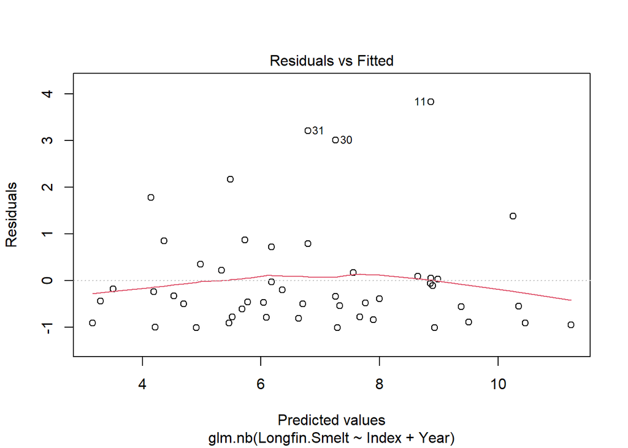

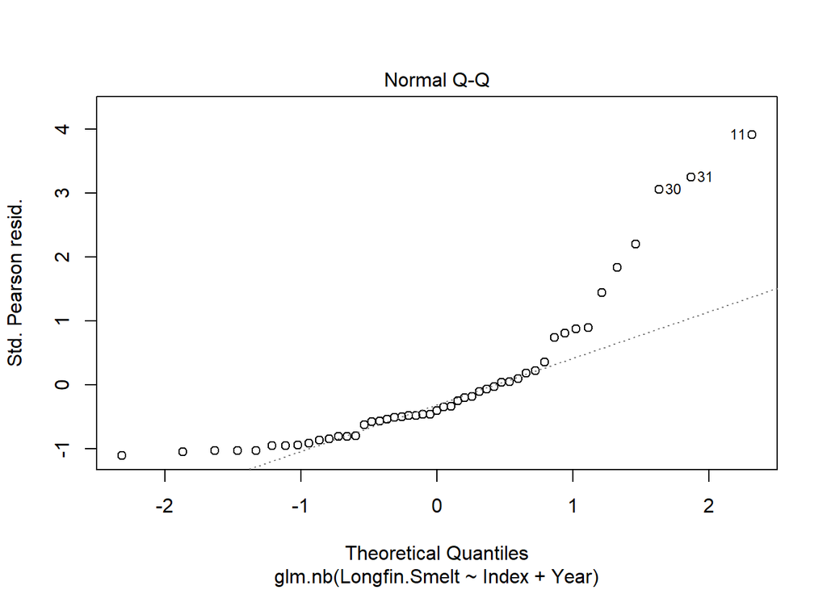

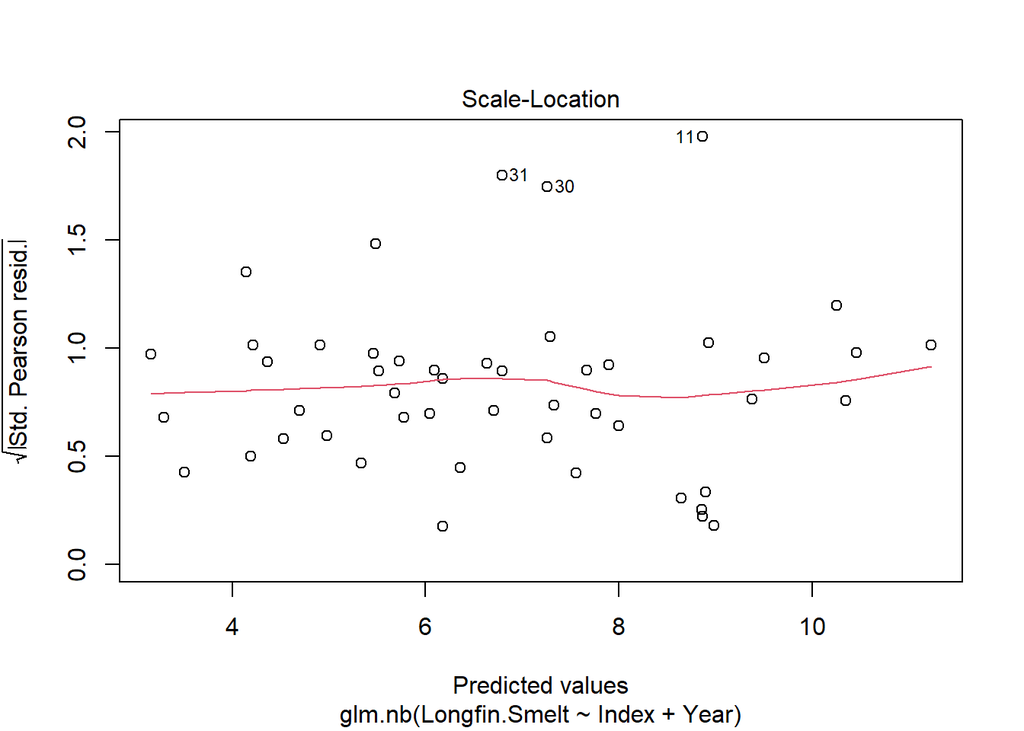

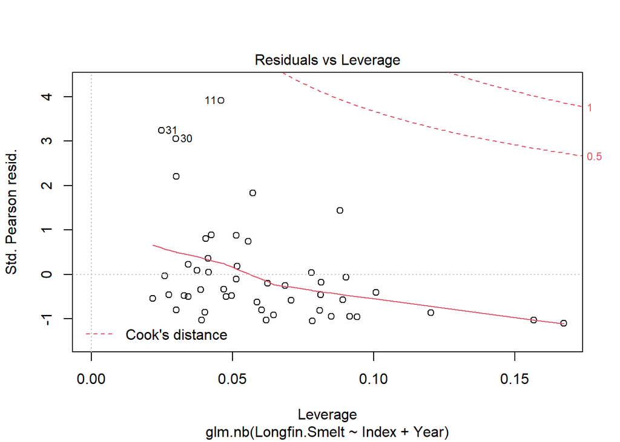

```r
plot(nb4)
```

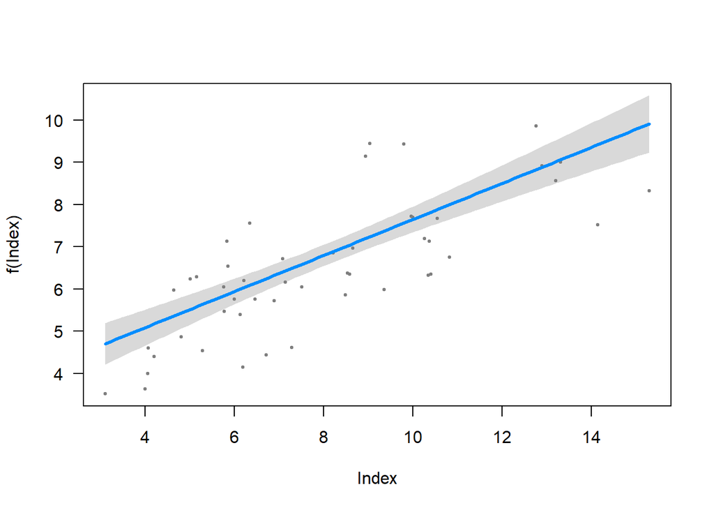

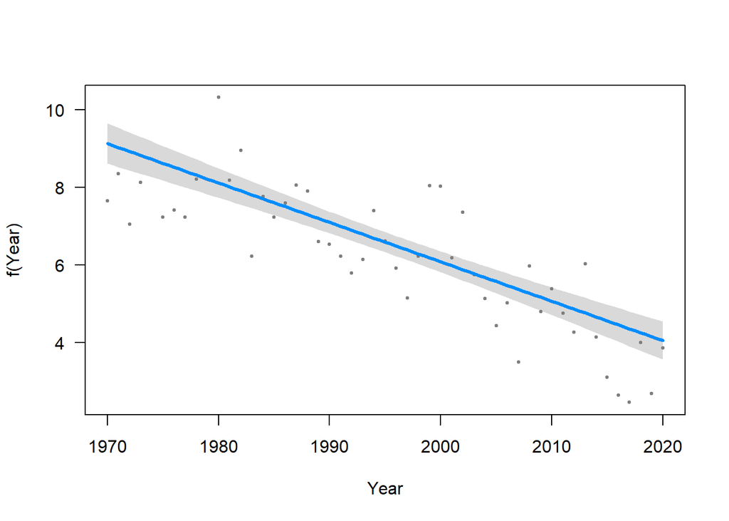

```r
visreg(nb4)
```

Well, the q-q plot isn’t great, we may want to look at some alternative distributions or go to a GAM, but the basic story is pretty clear. Longfin Smelt like wet years.